# The AB10 System

Daniel Kaplan

We’ve examined the behavior of the dynamics of $\xi_{t+1} = g(\xi_t)$ near a fixed point $\xi^\star$. Our strategy was:

1. Define a new variable $x$ whose zero value is centered on the fixed point: $x = \xi - \xi^\star$.
2. Near the fixed point, approximate $g()$ as a straight-line function: $x_{n+1} = \alpha x_n + \beta$. But noticing thaat $x=0$ is a fixed point, we can simplify this to $x_{n+1} = \alpha x_n$. Calculating the numerical value of $\alpha$ is easy; it’s $\partial_\xi\, g(\xi^\star)$
3. Look for different behaviors for the trajectory for different values of $\alpha$. We found only four such behaviors.

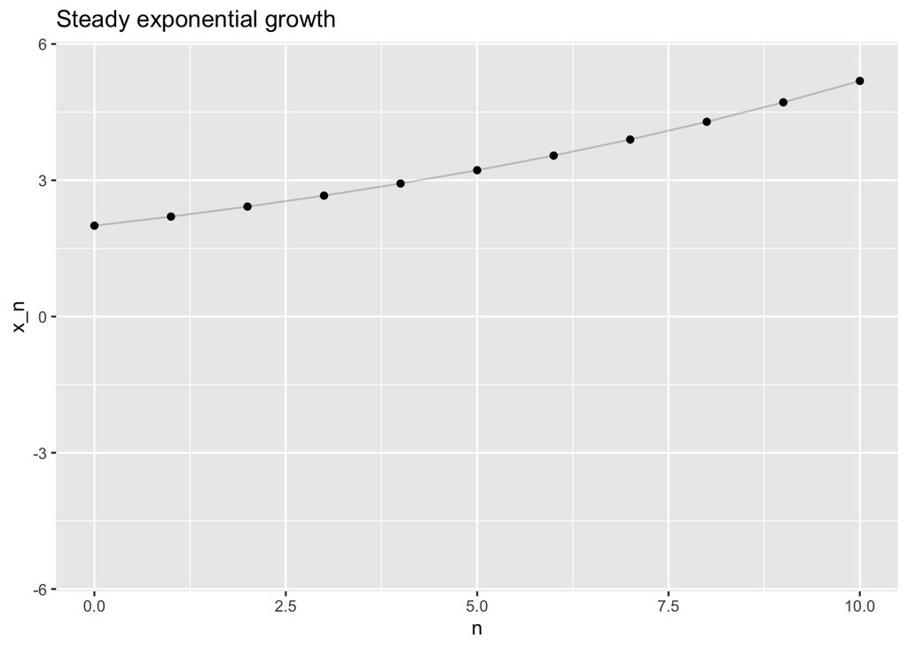

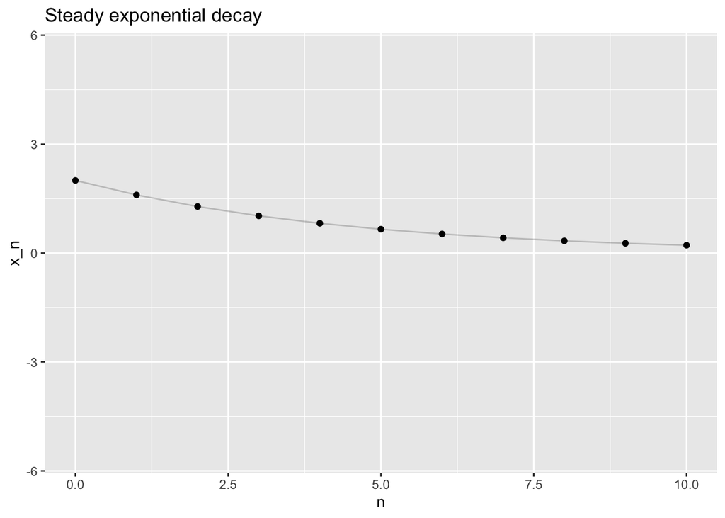

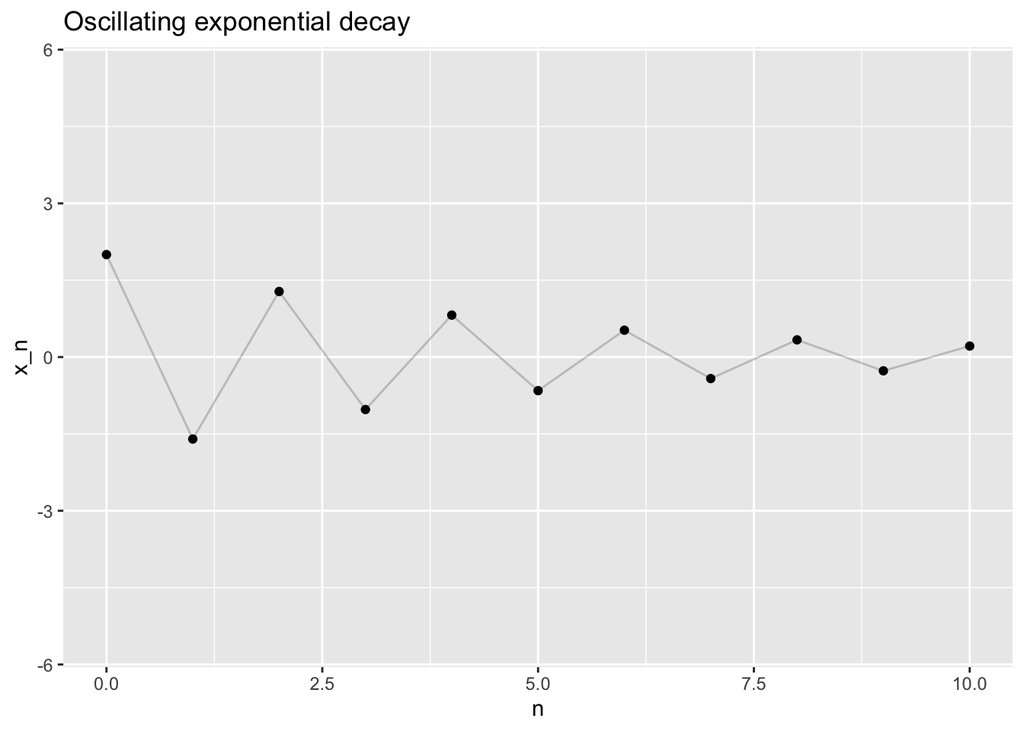

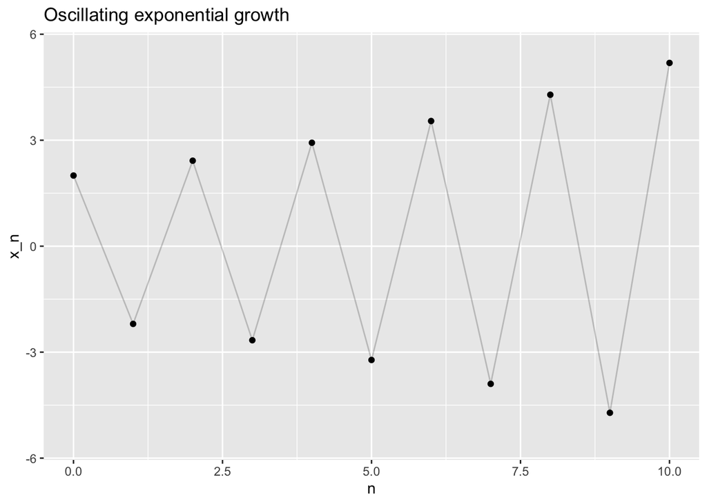

Now we’re going to examine dynamical systems that still involve linear functions near a fixed point, but where the state ${\mathbf S}$ has two components: $(x_n, y_n)$. For instance, $x_n$ might be the population of adult rabbits at generation $n$ and $y_n$ the population of baby rabbits. The system will have two dynamical functions. We’re going to start with one of the functions being extremely simple.
$$\left( \begin{array}{c}x_{n+1}\\y_{n+1}\end{array}\right) = \underbrace{\left(\begin{array}{rcc}a x_n & + & b y_n\\ x_n& + & 0\end{array}\right)}_\mbox{explicit form} = \underbrace{\left(\begin{array}{cc}a & b\\1 & 0\end{array}\right)
\left(\begin{array}{c}x_n \\ y_n\end{array}\right)}_\mbox{matrix/vector form}$$
We’ll call this the “AB10” system, and we’ve written it in two entirely equivalent forms.

**Problem 1** In the AB10 system, set $a=1$ and $b=1$. Start an initial condition $(x_0=1, y_0 = 0)^T$. Iterate the system by hand, since this is such simple arithmetic, writing down your trajectory in this format:

| n | $x$ | $y$ |
| --- | --- | --- |
| 0 | $x_0 = 1$ | $y_0 = 0$ |
| 1 | $x_1 = \_\_\_$ | $y_1 = \_\_\_$ |
| 2 | $x_2 = \_\_\_$ | $y_2 = \_\_\_$ |
| 3 | $x_3 = \_\_\_$ | $y_3 = \_\_\_$ |
| 4 | $x_4 = \_\_\_$ | $y_4 = \_\_\_$ |
| 5 | $x_5 = \_\_\_$ | $y_5 = \_\_\_$ |

**Question tmp-1**: What is $(x_1, y_1)$?

1. (0, 0) []
2. (1, 0) []
3. (0, 1) []
4. (1, 1) (+) []

**Question tmp-2**: What is $(x_2, y_2)$?

1. (1, 0) []
2. (2, 0) []
3. (2, 1) (+) []
4. (2, 2) []

**Question tmp-3**: What is $(x_5, y_5)$?

1. (6, 4) []
2. (8, 4) []
3. (8, 5) (+) []
4. (9, 6) []

**Problem 2** It will be convenient to be able to perform such iterations on the computer. Among other things, this makes it easy to graph the results. You can use the `Iterate()` operator to do this.

The dynamical function used in `Iterate()` has to take two inputs. We’re familiar with such functions in R, for example,

`makeFun(a*x + b*y ~ x + y)`

But we also need the dynamic function to return *two* outputs. In R, multiple outputs need to be packaged up into a vector. The R `c()` function accomplishes this. Here’s an implementation of the system you just iterated by hand.

```r
G <- makeFun(c(a*x + b*y, 1*x + 0*y) ~ x + y, a=1, b=1)
Traj <- Iterate(G, x0=c(1,0), n=5)
```

ASIDE: We wrote `1*x + 0*y` as the second element of the function. Of course, we could have written simply `x`, but we wanted to be explicit about how the `x` relates to the AB10 dynamics.

**Technique** Plot the trajectory.

The output of `Iterate()` has in this case three columns, one column for $n$ and one column for each of the state variables. There are three conventional ways to plot the trajectory.

1. Plot `x ~ n`. This shows how `x` changes step-by-step. This graph is called the “time series of $x$.”
2. Plot `y ~ n`. Similar to (i), but for $y$. This graph is called the “time series of $y$.”
3. Plot `y ~ x`. This graph is called a “trajectory plot” or a “state-space plot” because it shows the full $(x,y)$ state at each $n$.

You can make any of these plots in the sandbox. The basic structure of the plotting command will be the same in each case, just the tilde expression will vary between (i), (ii), and (iii).

```r
gf_point( tilde_expression, data = Traj) %>%
  gf_path(alpha = 0.2)
```

For a trajectory plot, it can be nice to add a little label to each dot to remind you what was the value of $n$. You would do this in the following way:

```r
gf_point(y ~ x, data = Traj) %>%
  gf_path(alpha = 0.2) %>%
  gf_text(label = ~ n, hjust=1, vjust=2)
```

Make all three kinds of plot—the two different time series and the state-space plot—and make sure you understand the differences. Both styles of plot are useful.

```r
G <- makeFun(c(a*x + b*y, x) ~ x + y, a=0.64, b=0.38)
Traj <- Iterate(G, x0=c(0.3, 0.9), 10, list(a=0.4, b=-0.28))
gf_point(x ~ n, data = Traj) %>% gf_path(alpha=0.2) %>%
  gf_text(label = ~ n, hjust=2, vjust=1)
```

[output not shown]

**Question tmp-4**: Which type of plot is this?

1. A state-space plot []
2. The time series of $y$ []
3. The time series of $x$ (+) [Yes, $x$ is on the vertical axis and $n$ on the horizontal axis.]
4. None of the above. []

**Question tmp-5**: What type of behavior does the trajectory show?

1. Steady exponential convergence to the fixed point at (0,0) []
2. Oscillatory exponential convergence to the fixed point []
3. Oscillatory exponential divergence from the fixed point []
4. Steady exponential divergence from the fixed point []
5. None of the above (+) [The oscillations shrink, but the movement is **away** from the fixed point.]

**Question tmp-6**: Using the sandbox, change the parameters of the system to $a=0.4$ and $b=-0.28$. What kind of behavior does the time series of $x$ show?

1. Steady exponential convergence to the fixed point at (0,0) []
2. Oscillatory exponential convergence to the fixed point (+) [But here the oscillation has a longer period than we have seen before.]
3. Oscillatory exponential divergence from the fixed point []
4. Steady exponential divergence from the fixed point []
5. None of the above. []

**Question tmp-7**: Using the sandbox, and keeping the parameters of the system at $a=0.4$ and $b=-0.28$, make a state-space plot of the trajectory. What’s the pattern seen in the state-space plot?

1. A straight in path to the fixed point []
2. A spiral in toward the fixed point (+) []
3. A random walk toward the fixed point []
4. Circling the fixed point at a constant distance from it []